# Risk Theory 2020/21 Assignment 5

Jiyeon Kim (12470236), Younjoo Mo (12475440)

5/16/2021

# Computing the Loimaranta efficiency

## 1 Storing the BM system in R

```r
## BM class now: 1 2 3 4 5 6 7 8 9 10 11 12 13 14 ## in case of
Next <- rbind(c( 2, 3, 4, 5, 6, 7, 8, 9,10,11, 12,13, 14,14), ## 0 claims
              c( 1, 1, 1, 1, 2, 3, 4, 5, 6, 7, 7, 8, 8, 9),   ## 1 claim
              c( 1, 1, 1, 1, 1, 1, 1, 1, 2, 3, 3, 4, 4, 5),   ## 2 claims
              c( 1, 1, 1, 1, 1, 1, 1, 1, 1, 1, 1, 1, 1, 1))   ## 3+ claims
BM.frac <- c(120,100,90,80,70,60,55,50,45,40,37.5,35,32.5,30)/100

FillP <- function(p) {
  PP <- matrix(0, nrow=14, ncol=14)
  for (b in 1:14) {
    for (k in 1:4) {
      PP[b,Next[k,b]] <- PP[b,Next[k,b]] + p[k] ## k-1 = number of claims
    }
  }
  return(PP)
}
```

#### Question 1(a)

According to Table 6.1, the driver’s BM class could be 8, 4, or 1 in the next year.

$$\begin{align}
& P_{78} = Pr\big[0 \text{ claims}\big] = 0.65 \\
& P_{74} = Pr\big[1 \text{ claims}\big] = 0.20 \\
& P_{71} = Pr\big[2 \text{ claims}\big] + Pr\big[3^+ \text{ claims}\big] = 0.10 + 0.05 = 0.15 \\
& \text{Otherwise, } P_{7j} = 0
\end{align}$$

#### Question 1(b)

```r
FillP(c(0.65, 0.20, 0.10, 0.05))[7,]  ## the same result as Question 1(a)
```

```
##  [1] 0.15 0.00 0.00 0.20 0.00 0.00 0.00 0.65 0.00 0.00 0.00 0.00 0.00 0.00
```

## 2 Approximating the steady-state distribution

```r
# Using P^1024

lam <- 0.05; eps <- 0.0001
lams <- c(lam*(1-eps), lam*(1+eps))
b <- c(0,0)  ## to store st-state premiums

for (i in 1:2) {
  pp <- dpois(0:2, lams[i])     ## prob of 0, 1, 2 claims
  P <- FillP(c(pp,1-sum(pp)))   ## 1-step transition matrix
  for (k in 1:10) {P <- P%*%P}  ## P is now P^1024
  stst <- P[nrow(P),]           ## bottom row of P is approx st-state dist
  b[i] <- sum(stst*BM.frac)     ## st-state premium
}
options(digits=12)
(log(b[2])-log(b[1])) / (log(lams[2])-log(lams[1])) ## e(0.05) = 0.103040331"546"
```

```
## [1] 0.103040331546
```

#### Question 2(a)

```r
range(apply(P, 2, sd))
```

```
## [1] 3.00703578913e-20 1.11022302463e-16
```

14 standard deviations are within the range of two extremely small numbers. So we may consider each column of $P^{1024}$ consists of one same value.

#### Question 2(b)

```r
range(apply(P, 1, sum)) - 1
```

```
## [1] 1.19904086660e-14 1.24344978758e-14
```

14 difference-from-1 are within the range of two extremely small numbers. So we may consider sum of each row is 1.

## 3 Exact methods to find the steady-state distribution

```r
stst <- eigen(t(P))$vectors[,1]
stst <- Re(stst/sum(stst))  ## enforce sum=1, take real part only
```

#### Question 3

```r
# Using eigenvectors

lam <- 0.05; eps <- 0.0001
lams <- c(lam*(1-eps), lam*(1+eps))
b <- c(0,0)  ## to store st-state premiums

for (i in 1:2) {
  pp <- dpois(0:2, lams[i])        ## prob of 0, 1, 2 claims
  P <- FillP(c(pp,1-sum(pp)))      ## 1-step transition matrix
  stst <- eigen(t(P))$vectors[,1]  ## eigenvector corresponding to the eigenvalue 1
  stst <- Re(stst/sum(stst))       ## enforce sum=1, take real part only
  b[i] <- sum(stst*BM.frac)        ## st-state premium
}
options(digits=12)
(log(b[2])-log(b[1])) / (log(lams[2])-log(lams[1])) ## e(0.05) = 0.103040331"436"
```

```
## [1] 0.103040331436
```

#### Question 4

```r
# Using RSST

lam <- 0.05; eps <- 0.0001
lams <- c(lam*(1-eps), lam*(1+eps))
b <- c(0,0)  ## to store st-state premiums

for (i in 1:2) {
  pp <- dpois(0:2, lams[i])                ## prob of 0, 1, 2 claims
  P <- FillP(c(pp,1-sum(pp)))              ## 1-step transition matrix
  stst <- rep(1,14)%*%solve(diag(14)-P+1)  ## l = 1vec * inverse(I-P+1)
  b[i] <- sum(stst*BM.frac)                ## st-state premium
}
options(digits=12)
(log(b[2])-log(b[1])) / (log(lams[2])-log(lams[1])) ## e(0.05) = 0.103040331"379"
```

```
## [1] 0.103040331379
```

## 4 Simulation method

```r
options(digits=6); set.seed(666)
TMax <- 100; NSim <- 10000; FinalBM <- rep(0,NSim); lam <- 0.05
for (n in 1:NSim) {
  cn <- rpois(TMax,lam)                     ## 100 claim numbers for 100 years
  cn <- pmin(cn,3) + 1                      ## convert claim nbrs into 1,2,3,4 for 0,1,2,3+ claims
  BM <- 14                                  ## start in BM class 14
  for (i in 1:TMax) {BM <- Next[cn[i],BM]}  ## move among classes for 100 years
  FinalBM[n] <- BM                          ## the final BM class at the end of 100 years
}
100*table(FinalBM)/NSim  ## percentage of sim’s that ended up in class 1,...,14
```

```
## FinalBM
##     1     2     3     4     5     6     7     8     9    10    11    12    13
##  0.02  0.03  0.10  0.09  0.18  0.37  0.74  1.25  4.54  4.53  4.35  4.00  3.53
##    14
## 76.27
```

```r
mean(BM.frac[FinalBM])  ## the estimate for b(0.05)
```

```
## [1] 0.325105
```

```r
sd(BM.frac[FinalBM])
```

```
## [1] 0.060736
```

#### Question 5

```r
# Using eigenvectors to compute b(lam=0.05)

lam <- 0.05; eps <- 0.0001

for (i in 1:2) {
  pp <- dpois(0:2, lam)            ## prob of 0, 1, 2 claims
  P <- FillP(c(pp,1-sum(pp)))      ## 1-step transition matrix
  stst <- eigen(t(P))$vectors[,1]  ## eigenvector corresponding to the eigenvalue 1
  stst <- Re(stst/sum(stst))       ## enforce sum=1, take real part only
  b <- sum(stst*BM.frac)           ## st-state premium
}
b
```

```
## [1] 0.326079
```

```r
0.995*b; 1.005*b  ## 0.325 is in between these two values.
```

```
## [1] 0.324448
```

```
## [1] 0.327709
```

#### Question 6(a)

$$\begin{align}
& \frac{\log\big[0.998 \cdot b(\lambda(1+\epsilon))\big] - \log\big[1.002 \cdot b(\lambda(1-\epsilon))\big]}{
\log\big[\lambda(1+\epsilon)\big] - \log\big[\lambda(1-\epsilon)\big]
} \\
& = \frac{\log\big[0.998\big] + \log\big[b(\lambda(1+\epsilon))\big] - \log\big[1.002\big] - \log\big[b(\lambda(1-\epsilon))\big]}{
\log\big[\lambda(1+\epsilon)\big] - \log\big[\lambda(1-\epsilon)\big]
} \hspace{3ex} (\because \log xy = \log x + \log y) \\
& = \frac{\log\big[b(\lambda(1+\epsilon))\big] - \log\big[b(\lambda(1-\epsilon))\big]}{
\log\big[\lambda(1+\epsilon)\big] - \log\big[\lambda(1-\epsilon)\big]
} + \frac{\log\big[1-0.002\big] - \log\big[1+0.002\big]}{\log(\lambda) + \log(1+\epsilon) - \log(\lambda) - \log(1-\epsilon)}
\hspace{3ex} (\because \log xy = \log x + \log y) \\
& \approx e(\lambda) - \frac{0.004}{2\epsilon}
\hspace{3ex} (\because \log(1+x) \approx x \hspace{1ex} \text{ for small } |x|)
\end{align}$$

#### Question 6(b)

```r
b <- c(0,0)  ## to store st-state premiums

for (j in 1:2){
  options(digits=6); set.seed(666) # use 5 different seed numbers
  TMax <- 100; NSim <- 10000; FinalBM <- rep(0,NSim); lam <- 0.05; eps <- 0.0001
  lams <- c(lam*(1-eps), lam*(1+eps))

  for (n in 1:NSim){
    cn <- rpois(TMax,lams[j])
    cn <- pmin(cn,3) + 1
    BM <- 14
    for (i in 1:TMax) {BM <- Next[cn[i],BM]}
    FinalBM[n] <- BM
    b[j] <- mean(BM.frac[FinalBM])
    }
  }

options(digits=12)
(log(b[2])-log(b[1])) / (log(lams[2])-log(lams[1]))
```

```
## [1] 0
```

```r
e.lam <- c(0, 0.229825178921, 0.230147830898, 0, 0.0383113871671)
names(e.lam) <- c("set.seed(666)", "set.seed(2)", "set.seed(3)", "set.seed(4)", "set.seed(5)")
e.lam  ## five e(lam=0.05) estimates with eps=0.0001
```

```
##   set.seed(666)     set.seed(2)     set.seed(3)     set.seed(4)     set.seed(5)
## 0.0000000000000 0.2298251789210 0.2301478308980 0.0000000000000 0.0383113871671
```

The $e(\lambda)$ value in Q6(b) fluctuates as the randomly generated sample of claim number is changed. $e(\lambda)$ with the seed number 2 and 3 are about twice as large as that in Q3/Q4, while $e(\lambda)$ from the seed number 666, 4, and 5 are smaller than the value in Q3/Q4.

#### Question 6(c)

```r
b <- c(0,0)  ## to store st-state premiums

for (j in 1:2){
  options(digits=6); set.seed(666) # use 5 different seed numbers
  TMax <- 100; NSim <- 10000; FinalBM <- rep(0,NSim); lam <- 0.05; eps <- 0.1
  lams <- c(lam*(1-eps), lam*(1+eps))

  for (n in 1:NSim){
    cn <- rpois(TMax,lams[j])
    cn <- pmin(cn,3) + 1
    BM <- 14
    for (i in 1:TMax) {BM <- Next[cn[i],BM]}
    FinalBM[n] <- BM
    b[j] <- mean(BM.frac[FinalBM])
  }
}

options(digits=12)
(log(b[2])-log(b[1])) / (log(lams[2])-log(lams[1]))
```

```
## [1] 0.0963273304208
```

```r
e.lam <- c(0.0963273304208, 0.102596086262, 0.103786826535, 0.102078306065, 0.102988692989)
names(e.lam) <- c("set.seed(666)", "set.seed(2)", "set.seed(3)", "set.seed(4)", "set.seed(5)")
e.lam  ## five e(lam=0.05) estimates with eps=0.1
```

```
##   set.seed(666)     set.seed(2)     set.seed(3)     set.seed(4)     set.seed(5)
## 0.0963273304208 0.1025960862620 0.1037868265350 0.1020783060650 0.1029886929890
```

The $e(\lambda)$ value in Q6(c) is much closer to that in Q3/Q4, compared with the result of Q6(b). And $e(\lambda)$ in Q6(c) fluctuates less.

## 5 Some commercially attractive variations

#### Question 7

```r
# Waiving the first claim in leap years

options(digits=6); set.seed(666)
TMax <- 100; NSim <- 10000; FinalBM <- rep(0,NSim); lam <- 0.05
for (n in 1:NSim) {
  cn <- rpois(TMax,lam)                     ## 100 claim numbers for 100 years
  cn[(1:25)*4] <- ifelse(cn[(1:25)*4]>=1, cn[(1:25)*4]-1, 0)
  cn <- pmin(cn,3) + 1                      ## convert claim nbrs into 1,2,3,4 for 0,1,2,3+ claims
  BM <- 14                                  ## start in BM class 14
  for (i in 1:TMax) {BM <- Next[cn[i],BM]}  ## move among classes for 100 years
  FinalBM[n] <- BM                          ## the final BM class at the end of 100 years
}

100*table(FinalBM)/NSim  ## percentage of sim’s that ended up in class 1,...,14
```

```
## FinalBM
##     3     4     5     6     7     8     9    10    11    12    13    14
##  0.03  0.05  0.02  0.19  0.36  0.69  0.71  4.82  4.16  4.00  0.65 84.32
```

```r
mean(BM.frac[FinalBM])  ## the estimate for b(0.05)***
```

```
## [1] 0.314528
```

```r
sd(BM.frac[FinalBM])
```

```
## [1] 0.041303
```

The new steady-state premium(0.314528) decreased to around 97% of the original one(0.325105).

#### Question 8(a)

```r
# Bonus guarantee

add.class <- rbind(c(15:20, 20), 9:15, 5:11, 1:7)
Next20 <- cbind(Next[,1:13], add.class); Next20
```

```
##      [,1] [,2] [,3] [,4] [,5] [,6] [,7] [,8] [,9] [,10] [,11] [,12] [,13] [,14]
## [1,]    2    3    4    5    6    7    8    9   10    11    12    13    14    15
## [2,]    1    1    1    1    2    3    4    5    6     7     7     8     8     9
## [3,]    1    1    1    1    1    1    1    1    2     3     3     4     4     5
## [4,]    1    1    1    1    1    1    1    1    1     1     1     1     1     1
##      [,15] [,16] [,17] [,18] [,19] [,20]
## [1,]    16    17    18    19    20    20
## [2,]    10    11    12    13    14    15
## [3,]     6     7     8     9    10    11
## [4,]     2     3     4     5     6     7
```

```r
BM.frac20 <- c(BM.frac, rep(BM.frac[14], 6)); BM.frac20
```

```
##  [1] 1.200 1.000 0.900 0.800 0.700 0.600 0.550 0.500 0.450 0.400 0.375 0.350
## [13] 0.325 0.300 0.300 0.300 0.300 0.300 0.300 0.300
```

#### Question 8(b)

```r
FillP20 <- function(p) {
  PP <- matrix(0, nrow=20, ncol=20)
  for (b in 1:20) {
    for (k in 1:4) {
      PP[b,Next20[k,b]] <- PP[b,Next20[k,b]] + p[k] ## k-1 = number of claims
    }
  }
  return(PP)
}
```

#### Question 8(c)

```r
# Using eigenvectors to compute b(lam=0.05) under the extended system

lam <- 0.05; eps <- 0.0001

for (i in 1:2) {
  pp <- dpois(0:2, lam)            ## prob of 0, 1, 2 claims
  P <- FillP20(c(pp,1-sum(pp)))    ## 1-step transition matrix
  stst <- eigen(t(P))$vectors[,1]  ## eigenvector corresponding to the eigenvalue 1
  stst <- Re(stst/sum(stst))       ## enforce sum=1, take real part only
  b <- sum(stst*BM.frac20)         ## st-state premium
}

b
```

```
## [1] 0.303072
```

The new steady-state premium(0.303072) decreased to around 93% of the original one(0.325105).

#### Question 9(a)

```r
lambdas <- (1:100)/200
prop <- rep(0, 100); b14 <- rep(0,100); b20 <- rep(0,100)

for(i in 1:100) {
    pp <- dpois(0:2, lambdas[i])         ## prob of 0, 1, 2 claims

    P14 <- FillP(c(pp,1-sum(pp)))        ## 1-step transition matrix
    P20 <- FillP20(c(pp,1-sum(pp)))

    stst14 <- eigen(t(P14))$vectors[,1]  ## eigenvector corresponding to the eigenvalue 1
    stst20 <- eigen(t(P20))$vectors[,1]

    stst14 <- Re(stst14/sum(stst14))     ## enforce sum=1, take real part only
    stst20 <- Re(stst20/sum(stst20))

    b14[i] <- sum(stst14*BM.frac)        ## st-state premium
    b20[i] <- sum(stst20*BM.frac20)

    prop[i] <- b20[i] / b14[i]
  }

prop
```

```
##   [1] 0.993267 0.986412 0.979448 0.972394 0.965268 0.958092 0.950892 0.943696
##   [9] 0.936534 0.929443 0.922458 0.915622 0.908977 0.902570 0.896446 0.890654
##  [17] 0.885242 0.880256 0.875740 0.871737 0.868281 0.865406 0.863135 0.861486
##  [25] 0.860470 0.860088 0.860332 0.861189 0.862634 0.864637 0.867160 0.870160
##  [33] 0.873589 0.877396 0.881527 0.885928 0.890543 0.895321 0.900208 0.905157
##  [41] 0.910124 0.915067 0.919950 0.924741 0.929413 0.933942 0.938312 0.942506
##  [49] 0.946514 0.950329 0.953946 0.957364 0.960584 0.963608 0.966439 0.969085
##  [57] 0.971551 0.973845 0.975974 0.977948 0.979773 0.981460 0.983015 0.984449
##  [65] 0.985768 0.986980 0.988094 0.989116 0.990053 0.990912 0.991698 0.992418
##  [73] 0.993077 0.993679 0.994229 0.994731 0.995191 0.995610 0.995993 0.996342
##  [81] 0.996661 0.996952 0.997217 0.997459 0.997680 0.997882 0.998066 0.998233
##  [89] 0.998386 0.998526 0.998653 0.998769 0.998875 0.998972 0.999060 0.999141
##  [97] 0.999214 0.999281 0.999343 0.999399
```

#### Question 9(b)

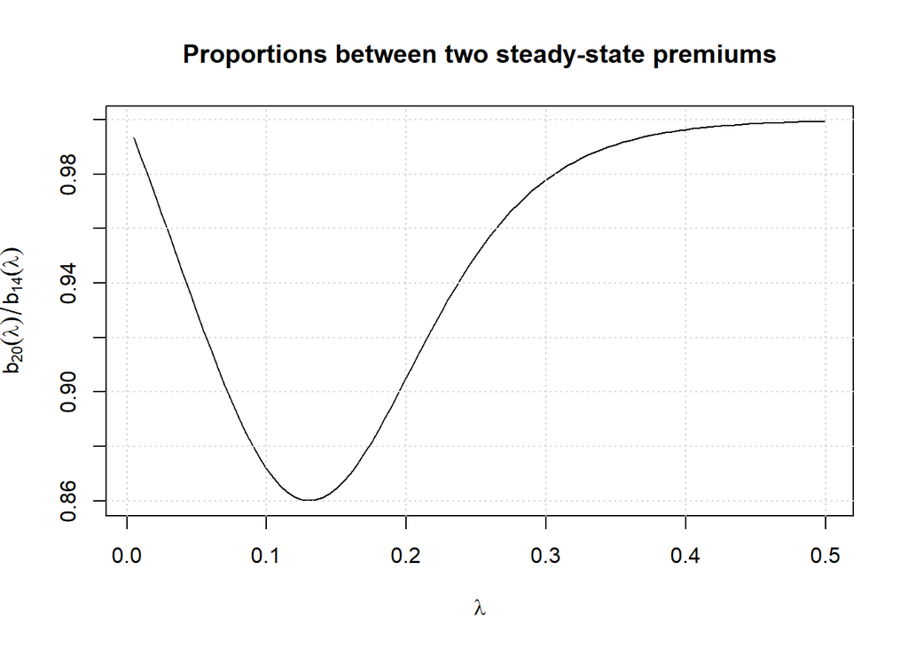

```r
plot(lambdas, prop, type="l",
  main="Proportions between two steady-state premiums",
  xlab=expression(lambda), ylab=expression(b[20](lambda) / b[14](lambda))); grid()
```

```r
lambdas[which(prop == min(prop))]
```

```
## [1] 0.13
```

The extended system would be the most beneficial for the drivers with claim frequency 0.13.